# 1. Découvrir l’écosystème `R`

Simon Gabay

31/05/2022

# `R` et les statistiques

## 1 `R`, `R GUI`, `RStudio`, `Rstudio cloud`

Attention

- `R` est un langage destiné aux statistiques et à la science des données
- `R GUI` est une interface (“GUI” pour *Graphical User Interface*)
- `RStudio` est une interface de programmation `open source`
- `Rstudio cloud` est une version en ligne de `RStudio`

Il est donc possible de programmer en `R` en dehors de `RStudio` (et de `Rstudio cloud`)

Pour vous aider (mais aussi pour m’aider dans mon cours), vous lisez actuellement un notebook. Il s’agit d’un mélange de code et de commentaires qui permet de simplifier l’apprentissage, mais aussi de documenter son travail. En cliquant sur le petit bouton “play” à droite des morceaux de code (en gris), vous exécutez ces derniers et obtenez les résultats.

### Préparer la session de travail

Nous devons préparer la session de travail, en désignant à `R` le dossier de notre ordinateur à partir duquel nous allons travailler pour qu’il trouve nos fichiers et qu’il y sauvegarde nos résultats.

Pour indiquer où se trouve le fichier de travail, deux solutions sont possibles:

- ou bien *via* le menu avec `Session>Set Working Directory>Choose Directory`
- ou bien directement dans `R` avec la commande `setwd` (pour *Set working directory*), qui s’utilise de cette manière.

```r
setwd("~/GitHub/UNIGE/CUSO_R/Cours_1")
```

**Attention!** Il convient de donner le chemin qui corredpond à votre configuration locale. Une fois la chose faite, cliquez sur `Run` (le bouton qui ressemble à *play*, à droite de la commande *supra*).

On peut vérifier que le chemin vers le dossier de travail a bien été pris en compte avec une autre commande: `getwd` (pour *Get working directory*):

```r
getwd()
```

```
## [1] "/Users/gabaysimon/GitHub/UNIGE/CUSO_R/Cours_1"
```

Tout est en ordre? Avançons!

## 2 Les fondamentaux

### 2.1 Premiers pas

Il faut faire la différence entre des chiffres et une chaine de caractère (entre guillemets).

```r
1+1
```

```
## [1] 2
```

```r
1+"chose"
```

```
## Error in 1 + "chose": non-numeric argument to binary operator
```

Si on met un chiffre entre guillemets, il devient une chaîne de caractère, et perd ses propriétés mathématiques:

```r
"1"+1
```

```
## Error in "1" + 1: non-numeric argument to binary operator
```

Je vais pouvoir manipuler des variables, auxquelles j’assigne une valeur avec `<-`. Je peux ensuite lui demander d’afficher le contenu de la variable en l’appelant (par son nom):

```r
a<-10
a
```

```
## [1] 10
```

```r
a+1
```

```
## [1] 11
```

Il est possible de vérifier le type d’une variable (parce qu’on ne sait pas toujours ce qu’il y a dedaans après quelques centaines de lignes de code…) avec la fonction `class()`

```r
a<-1
b<-"12"
class(a)
```

```
## [1] "numeric"
```

```r
class(b)
```

```
## [1] "character"
```

L’utilisation d’une variable est une manière simple de centraliser l’information à endroit, ce qui est le principe de base du développement informatique:

```r
a<-1
b<-2
c<-3
a+b+c
```

```
## [1] 6
```

```r
a^b+c # R respecte la priorité des opérations
```

```
## [1] 4
```

### 2.2 Les opérateurs

#### 2.2.1 opérateurs mathématiques

- `+` addition
- `-` soustraction
- `/` division
- `*` multiplication
- `ˆ` puissance

```r
a+b
```

```
## [1] 3
```

```r
a-b
```

```
## [1] -1
```

```r
a/b
```

```
## [1] 0.5
```

```r
a^b
```

```
## [1] 1
```

```r
a*b
```

```
## [1] 2
```

#### 2.2.2 opérateurs de comparaison

- `==` égal à
- `!=` est différent de

```r
1 == 1
```

```
## [1] TRUE
```

```r
1 == 2
```

```
## [1] FALSE
```

```r
1 != 1
```

```
## [1] FALSE
```

```r
2 != 2
```

```
## [1] FALSE
```

```r
a != b
```

```
## [1] TRUE
```

- `<` strictement inférieur à
- `>` strictement supérieur à
- `<=` inférieur ou égal à
- `>=` supérieur ou égal à

```r
1 > 2
```

```
## [1] FALSE
```

```r
1 < 2
```

```
## [1] TRUE
```

```r
1 <= 2
```

```
## [1] TRUE
```

```r
1 >= 2
```

```
## [1] FALSE
```

#### 2.2.3 opérateurs logiques

- `!` négation logique
- `&` et logique
- `|` ou logique

```r
a <- (1 < 2)
a
```

```
## [1] TRUE
```

```r
!a
```

```
## [1] FALSE
```

```r
b <- (2 > 3)
b
```

```
## [1] FALSE
```

```r
!b
```

```
## [1] TRUE
```

```r
a & b
```

```
## [1] FALSE
```

```r
a | b
```

```
## [1] TRUE
```

### 2.3 Les classes

#### 2.3.1 Vecteurs

On peut vérifier la longueur d’une variable:

```r
a<-1
b<-12
c<-12000
d<-"une voiture"
length(a)
```

```
## [1] 1
```

```r
length(b)
```

```
## [1] 1
```

```r
length(c)
```

```
## [1] 1
```

```r
length(d)
```

```
## [1] 1
```

Remarquons que nous obtenons toujours “1”, peu importe la longueur de la donnée stockée. C’est parce qu’il ne s’agit que d’un seul élément. Il est en effet possible qu’il y en ait plusieurs: il s’agit d’un vecteur:

```r
a<-c(1, 2, 3, 4, 5)
a
```

```
## [1] 1 2 3 4 5
```

```r
b<-c("a","b","c","d","e" )
b
```

```
## [1] "a" "b" "c" "d" "e"
```

```r
length(a)
```

```
## [1] 5
```

```r
length(b)
```

```
## [1] 5
```

Il existe une notation alternative, pour écrire le même vecteur plus rapidement, seulement avec les chiffres

```r
a <- 1:5
a
```

```
## [1] 1 2 3 4 5
```

```r
length(a)
```

```
## [1] 5
```

On peut afficher certains éléments du vecteur seulement

```r
a
```

```
## [1] 1 2 3 4 5
```

```r
a[2]
```

```
## [1] 2
```

```r
b[c(2,4)]
```

```
## [1] "b" "d"
```

```r
b[c(-2)]
```

```
## [1] "a" "c" "d" "e"
```

On peut remplacer le contenu du vecteur:

```r
b[2] = "zzzz"
b
```

```
## [1] "a"    "zzzz" "c"    "d"    "e"
```

```r
a[c(2,3)] = 200
a
```

```
## [1]   1 200 200   4   5
```

```r
a[c(2,3)] = c(300,400)
a
```

```
## [1]   1 300 400   4   5
```

On peu manipuler mathématiquement le contenu du vecteur

```r
c(1,2,3) + c(3,5,6)
```

```
## [1] 4 7 9
```

```r
4 * c(1,2,3)
```

```
## [1]  4  8 12
```

Il faut évidemment faire attention à la taille des vecteurs:

```r
c(1,2) + c(3,4,5)
```

```
## [1] 4 6 6
```

```r
c(1,2) + c(3,4,5,6)
```

```
## [1] 4 6 6 8
```

#### 2.3.2 Les listes

Une liste est un vecteur permettant de stocker des objets hétérogènes.

```r
uneListe<-list("toto",10,TRUE,c(14,15,7),c("truc","chose"))
uneListe
```

```
## [[1]]
## [1] "toto"
##
## [[2]]
## [1] 10
##
## [[3]]
## [1] TRUE
##
## [[4]]
## [1] 14 15  7
##
## [[5]]
## [1] "truc"  "chose"
```

On peut récupérer une élément dans une liste

```r
uneListe[[3]] #savoir s'il existe
```

```
## [1] TRUE
```

```r
uneListe[[4]][[2]] #récupérer la valeur
```

```
## [1] 15
```

#### 2.3.3 Data frames

```r
df <- data.frame(taille=c(173,175,168,172,173,170,175,172,180),
                 poids=c( 69, 81, 55, 64, 66, 70, 75, 71, 77),
                 genre=c( "M","M","F","F","F","M","M","F","F"),
                 row.names=c("Patrick","Jacques","Pauline","Marie","Eva","Eric", "Paul", "Christine","Madeleine")
                 )
df
```

```
##           taille poids genre
## Patrick      173    69     M
## Jacques      175    81     M
## Pauline      168    55     F
## Marie        172    64     F
## Eva          173    66     F
## Eric         170    70     M
## Paul         175    75     M
## Christine    172    71     F
## Madeleine    180    77     F
```

On peut récupérer les informations dans le data frame

```r
df["Patrick","poids"]
```

```
## [1] 69
```

Sélectionner le premier rang:

```r
df[1,]
```

```
##         taille poids genre
## Patrick    173    69     M
```

Sélectionner la première colonne:

```r
df[,1]
```

```
## [1] 173 175 168 172 173 170 175 172 180
```

Il est possible de “découper” des morceaux du tableau:

```r
df[1:3,c(2,3)]
```

```
##         poids genre
## Patrick    69     M
## Jacques    81     M
## Pauline    55     F
```

Je peux appeler les vecteurs par leur nom:

```r
df[1:3,c("poids","genre")]
```

```
##         poids genre
## Patrick    69     M
## Jacques    81     M
## Pauline    55     F
```

On peut accéder à des colonnes en ajoutant `$` suivi du nom de la colonne

```r
df$taille
```

```
## [1] 173 175 168 172 173 170 175 172 180
```

Pour récupérer des rangs en les choisissant:

```r
subset_df <- rbind(df[1:2, ], df[5, ])
subset_df
```

```
##         taille poids genre
## Patrick    173    69     M
## Jacques    175    81     M
## Eva        173    66     F
```

## 3 Des premières statistiques

### 3.1 Définitions: médiane, moyenne, écart type

On peut obtenir des informations statistiques simples sur notre échantillon comme (nous reprenons (presque) les définitions de l’INSEE): * La médiane: la valeur qui partage les données en deux parties égales. [def. INSEE](https://www.insee.fr/fr/metadonnees/definition/c1376)

```r
md<-median(df$poids)
md
```

```
## [1] 70
```

- La moyenne: la somme des données divisée par leur nombre [def. INSEE](https://www.insee.fr/fr/metadonnees/definition/c1970)

```r
#moyenne
mn<-mean(df$poids)
mn
```

```
## [1] 69.77778
```

- L’écart-type: il sert à mesurer la dispersion, ou l’étalement, d’un ensemble de valeurs autour de leur moyenne. Plus l’écart-type est faible, plus la population est homogène. [def. INSEE](https://www.insee.fr/fr/metadonnees/definition/c1913)

Dans cette image, la moyenne à une abscisse de 0, l’e premier est écart-type est noté avec le *σ* (*sigma*).

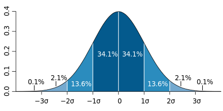

center 100%

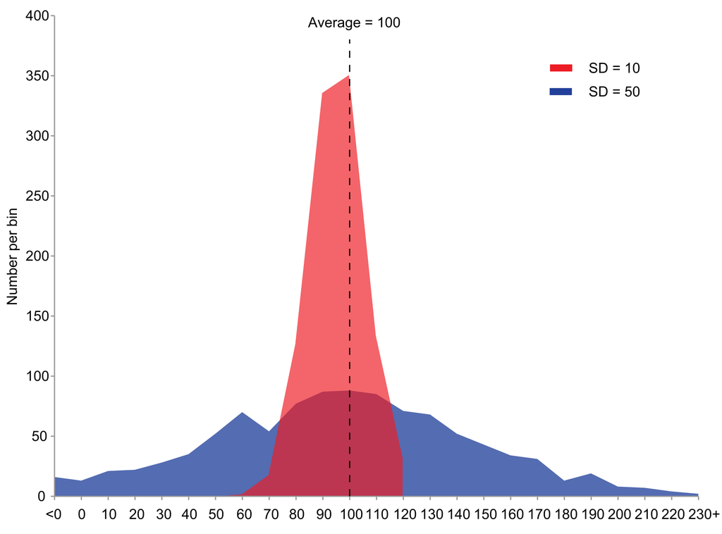

center 100%

```r
std<-sd(df$poids)
std
```

```
## [1] 7.693793
```

Il existe une fonction simple `summary()` qui nous donne quelques informations:

```r
summary(df$poids)
```

```
##    Min. 1st Qu.  Median    Mean 3rd Qu.    Max.
##   55.00   66.00   70.00   69.78   75.00   81.00
```

### 3.2 Des statistiques aux courbes

Ces informations nous permettent de décrire notre échantillon

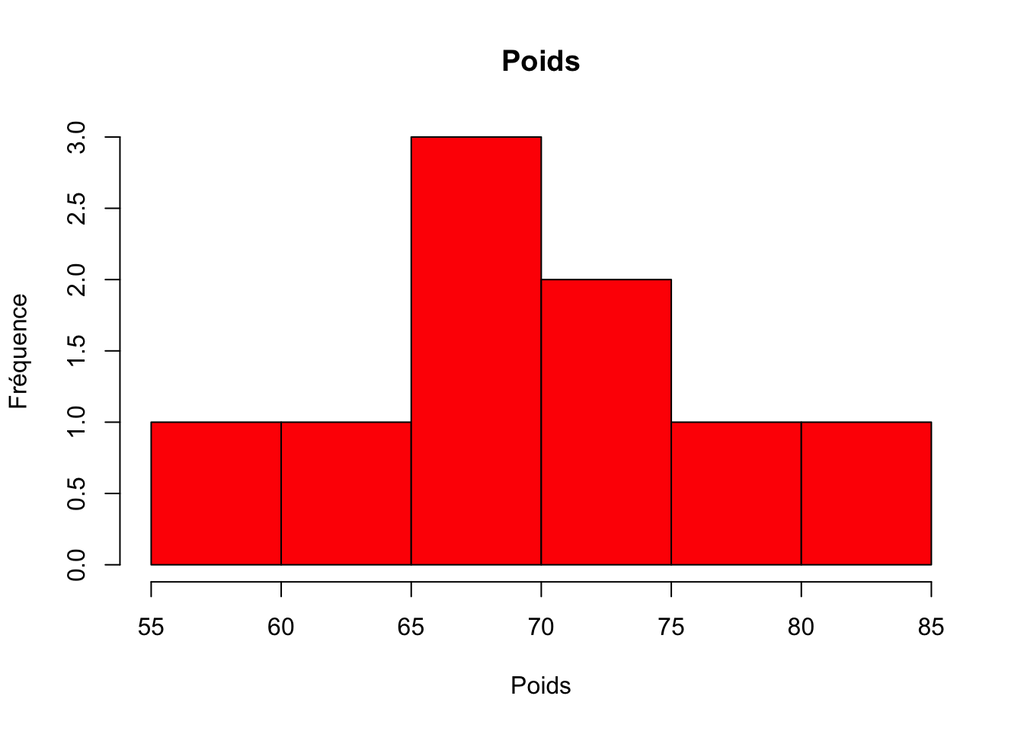

```r
# avec un histogramme
hist(df$poids,main="Poids",col="red",xlab="Poids",ylab="Fréquence")
```

On peut vérifier si la distribution est normale avec `qqnorm`. Pour qu’elle le soit, il faut que les points (qui dessinent une fonction de répartition *Φ*, *phi*) montent constamment, comme dans ces exemples:

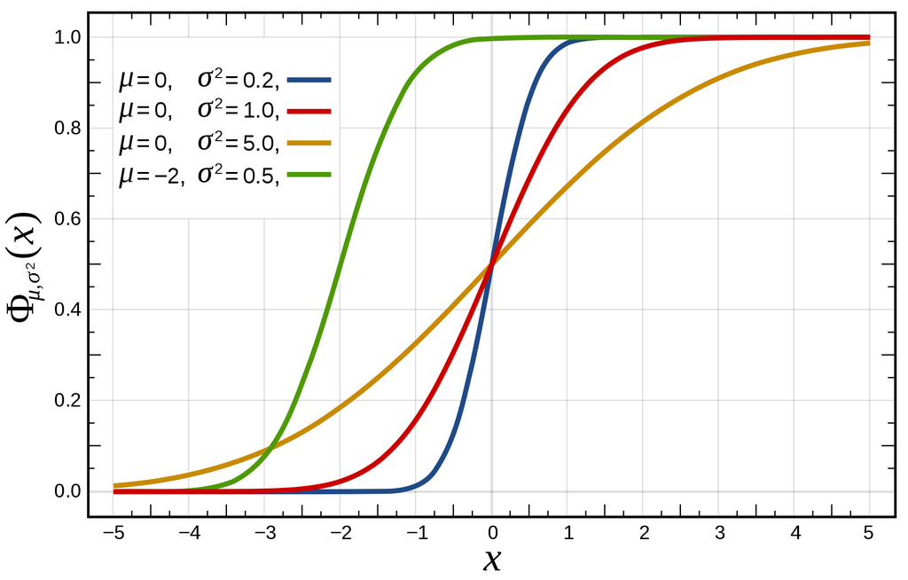

center 100%

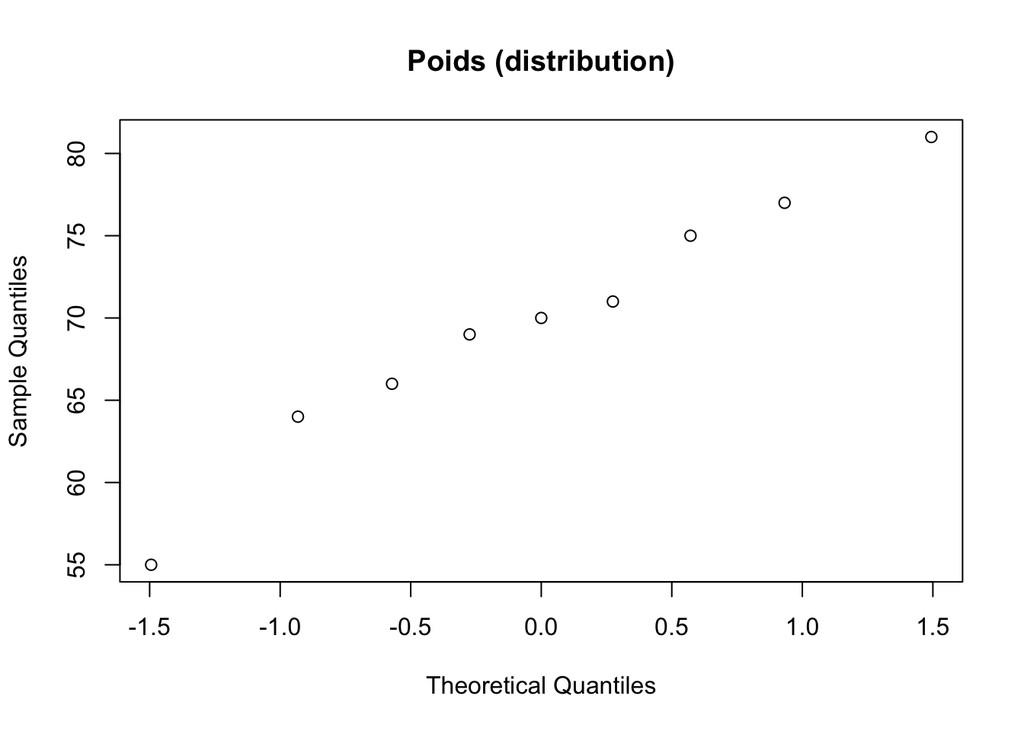

```r
qqnorm(df$poids,main="Poids (distribution)")
```

Si la répartition de nos données suivent une loi normale, nous devons obtenir une densité de probabilité en forme de cloche, comme ici:

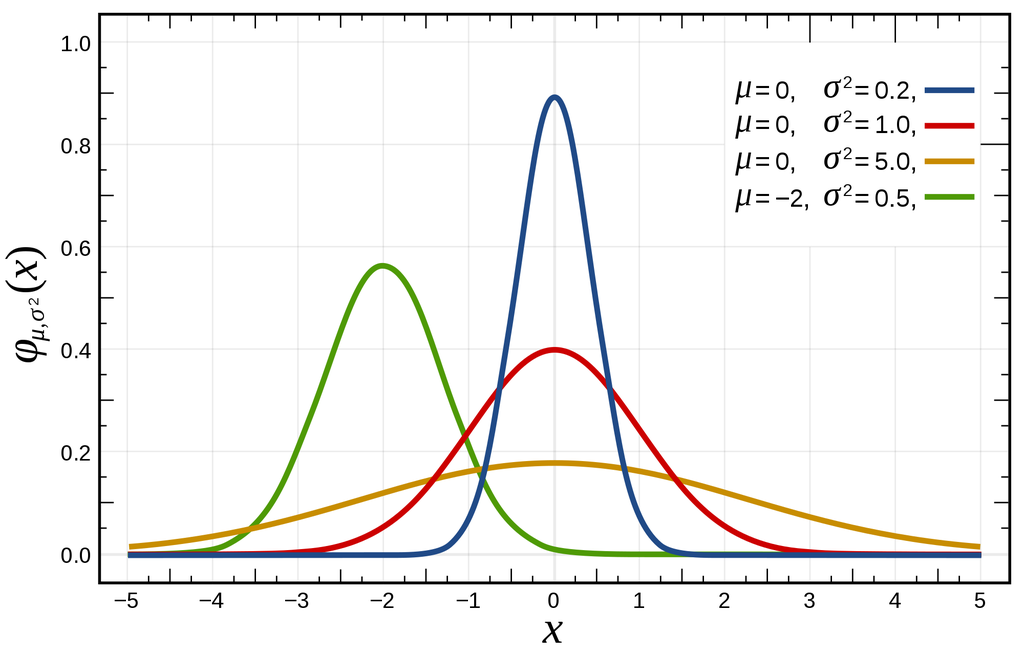

center 100%

Comme la distribution est normale, on peut superposer à notre un histogramme la courbe de densité qui lui est associée, mais aussi la moyenne et les *σ*. La fonction `dnorm()` qui calcule la densité de probabilité à *x* d’une distribution normale avec une moyenne *μ* et un écart-type *σ*. `abline()` permet de déssiner une ligne verticale et `curve()` une courbe. Rappelons ici que nous avons défini `mn` (la moyenne), `std` (l’écart type) quelques lignes plus haut: je peux donc les passer valeur des différents paramètres des fonctions que j’utilise.

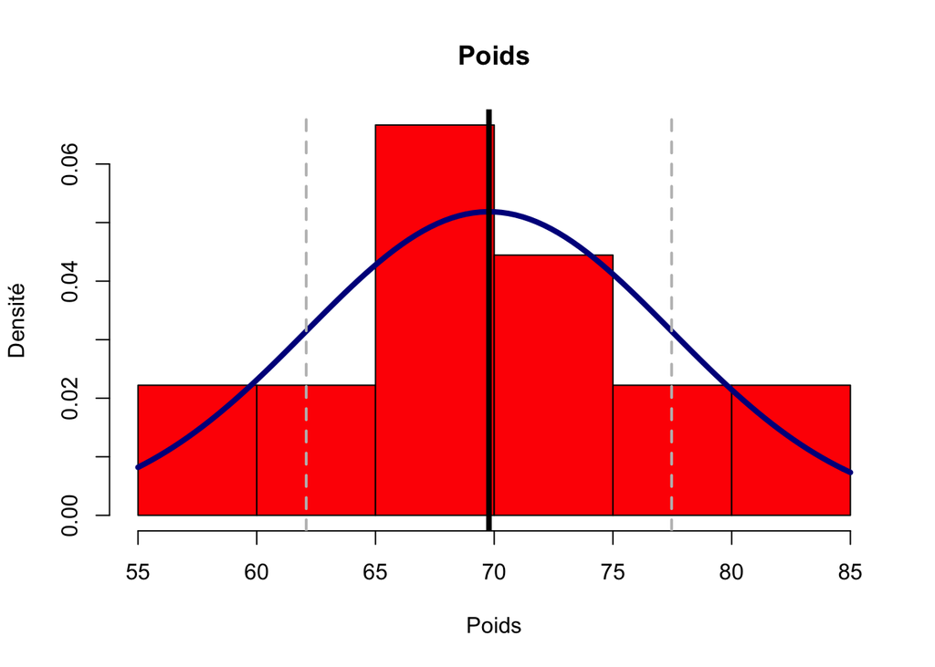

```r
#on affiche la densité plutôt que la fréquence en ordonnée avec l'argument `freq=F`
hist(df$poids,main="Poids",freq=F,col="red",xlab="Poids",ylab="Densité")
# On ajoute la fonction gaussienne. La valeur de x, celle des abcisses, n'a pas besoin d'être définie car c'est celle de l'histogramme. lwd (line width) définit l'épaisseur de la ligne.
curve(dnorm(x, mean=mn, sd=std), add=T, col="darkblue", lwd=4)
# On ajoute la moyenne
abline(v = mn, col = "black", lwd = 4)
#On ajoute les σ/quantiles. l'argument lty définit le type de trait: “blank” (0), “solid” (1), “dashed” (2), “dotted” (3), “dotdash” (4), “longdash” (5), “twodash” (6)
abline(v = mn-std, col = "grey", lwd = 2,lty=2)
abline(v = mn+std, col = "grey", lwd = 2,lty=2)
```

On peut aussi proposer d’autres visualisation, sous forme de “boîte à moustache” par exemple:

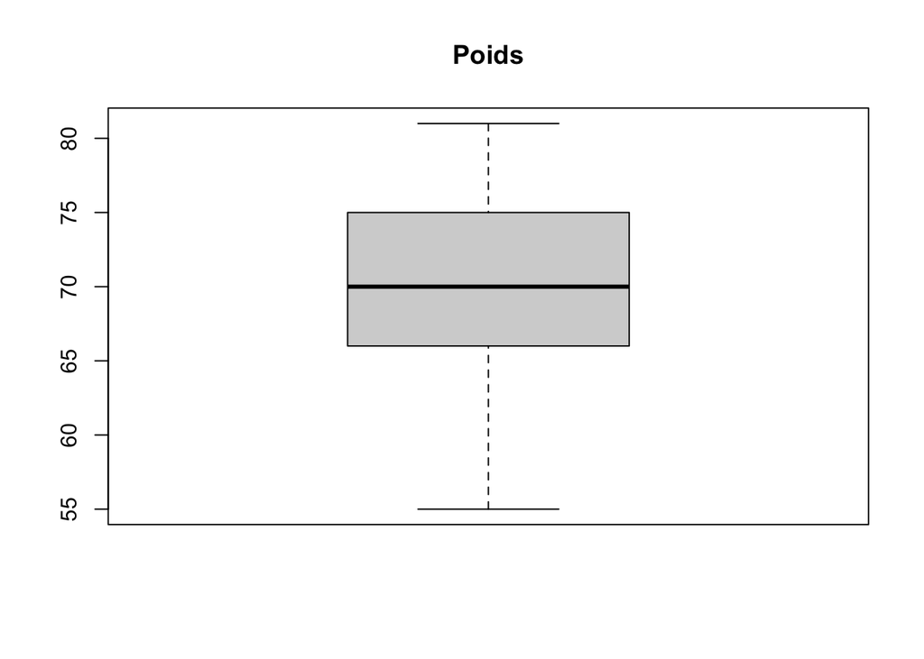

```r
boxplot(df$poids,main="Poids")
```

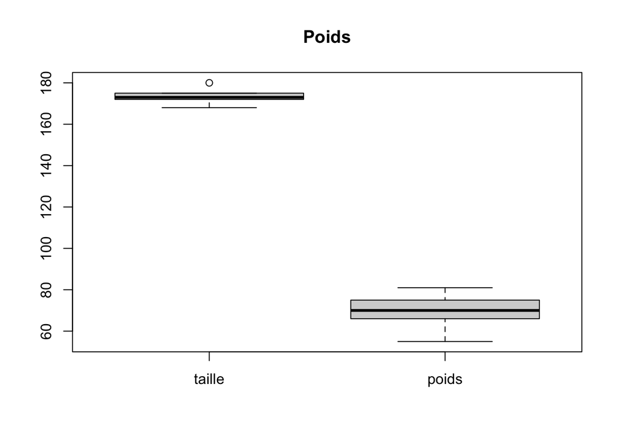

```r
#une boîte à moustache de la taille et du poids (assez inutile d'un point de vue graphique…)
boxplot(df[-3],main="Poids")
```

## 4 Automatisation des tâches (quelques principes d’algorithmie)

### 4.1 La boucle

Nous avons déjà vu une notion fondamentale d’informatique: **la variable**. Nous allons en voir une seconde, aussi importante et auss simple: **la boucle**. Il est possible de “boucler” pour répéter une tâche simple avec la fonction `for()`

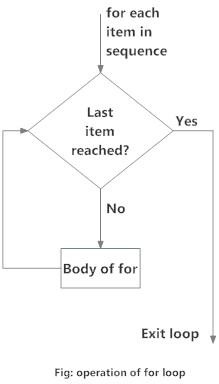

100% center

```r
for (i in 1:5){
  print(i)
}
```

```
## [1] 1
## [1] 2
## [1] 3
## [1] 4
## [1] 5
```

### 4.2 Le test

Il est possible d’ajouter des tests avec la fonction `if()`: si le test est validé, la fonction est appliquée.

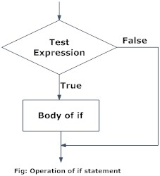

100% center

```r
for (i in df$genre){
  if(i=="M"){
    print("c'est un garçon")
  }
}
```

```
## [1] "c'est un garçon"
## [1] "c'est un garçon"
## [1] "c'est un garçon"
## [1] "c'est un garçon"
```

### 4.3 Le test II

Il est possible de prévoir des cas où le test n’est pas validé avec la fonction `else()`:

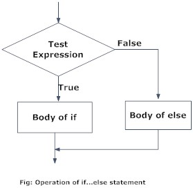

100% center

```r
for (i in df$genre){
  if(i=="M"){
    print("c'est un garçon")
  }else
  {print("c'est une fille")}
}
```

```
## [1] "c'est un garçon"
## [1] "c'est un garçon"
## [1] "c'est une fille"
## [1] "c'est une fille"
## [1] "c'est une fille"
## [1] "c'est un garçon"
## [1] "c'est un garçon"
## [1] "c'est une fille"
## [1] "c'est une fille"
```

### 4.4 Définir ses propres fonctions

Tout cela commence à faire beaucoup de code… Pourquoi ne pas se simplifier la tâche en enregistrant des fonctions dans un coin de notre ordinateur, et y faire appel ponctuellement? Cela permet d’alléger le script, et de centraliser des tâches que je vais beaucoup effectuer pour me simplifier la vie. Je vais donc créer une fonction à laquelle je vais donner un nom assez descriptif, et la remplir de ce que je veux.

```r
afficher_le_genre<-function(nom_de_variable){
                              for (i in nom_de_variable){
                                print(i)
                              }
}
```

Je peux désormais exécuter cette fonction simplement:

```r
afficher_le_genre(df$genre)
```

```
## [1] "M"
## [1] "M"
## [1] "F"
## [1] "F"
## [1] "F"
## [1] "M"
## [1] "M"
## [1] "F"
## [1] "F"
```

Si je commence à faire beaucoup de fonctions complexes et utile à d’autres personnes, je peux les transformer en `package` et les distribuer sous cette forme à l’ensemble de la communauté.

## Intermède

Ca fait beaucoup ? Je vous comprends… Heureusement `R` vous aide 7j/7, 24h/24 avec la fonction `help()`

```r
help(hist)
```

## 5 Les packages

**Pour cet exemple, nous allsons utiliser le pacakage rtweet, qui permet de télécharger des tweets, mais pour cela vous devez avoir un compte twitte**

### 5.1 Principe et installation

Nous avons vu jusqu’à présent une série de fonctions: `summary()`, `mean()`… Elles sont fournies avec `R`, mais il est possible d’en inventer soit même, et donc de les mettre à disposition des autres. Pour cela on les met dans un package, disponible en ligne, et que l’on peut télécharger avec la fonction `install.packages()` et on l’active avec `library()`.

(pensez à retirer le `#` qui est un commentaire, et désactive la ligne)

```r
#install.packages("rtweet")
library(rtweet)
```

Pour savoir si un package est installé, je peux explorer la liste `installed.packages()` ou bien directement demander si un package se trouve dans cette liste:

```r
View(installed.packages())
"rtweet" %in% rownames(installed.packages())
```

```
## [1] TRUE
```

On peut aussi effacer une librairie:

```r
remove.packages("rtweet")
```

```
## Removing package from '/Library/Frameworks/R.framework/Versions/4.1/Resources/library'
```

Il est possible de conditionner l’installation d’une bibliothèque à son absence sur la machine:

```r
if(!require("rtweet")){
  install.packages("rtweet")
  library(rtweet)
}
```

Nous pouvons désormais moissonner tweeter. Nous cherchons ceux qui mentionnent “Sciences_UNIGE”:

```r
tweets_UniGE <- search_tweets("Sciences_UNIGE", n = 1000)
```

Et nous pouvons voir le résultat (pour afficher le résultat dans un tableau séparé avec la fonction `View()`):

```r
#View(tweets_UniGE)
tweets_UniGE
```

```
## # A tibble: 195 × 90
##    user_id             status_id    created_at          screen_name text  source
##    <chr>               <chr>        <dttm>              <chr>       <chr> <chr>
##  1 1230800616626233344 15344899003… 2022-06-08 10:57:56 UNIL_CCD    "Le … Twitt…
##  2 1552880124          15344846881… 2022-06-08 10:37:13 Micropalae… "Ass… Twitt…
##  3 4480242322          15344369579… 2022-06-08 07:27:33 GRIDgva     "And… Twitt…
##  4 1159399667542712320 15344310400… 2022-06-08 07:04:02 sciences_U… "🚨 … Twitt…
##  5 1159399667542712320 15344304902… 2022-06-08 07:01:51 sciences_U… "#CE… Twitt…
##  6 1159399667542712320 15344304092… 2022-06-08 07:01:32 sciences_U… "Pro… Twitt…
##  7 1159399667542712320 15344292376… 2022-06-08 06:56:53 sciences_U… "So … Twitt…
##  8 1159399667542712320 15344291605… 2022-06-08 06:56:34 sciences_U… "htt… Twitt…
##  9 1159399667542712320 15344282534… 2022-06-08 06:52:58 sciences_U… "✅L… Twitt…
## 10 1159399667542712320 15344282032… 2022-06-08 06:52:46 sciences_U… "📢N… Twitt…
## # … with 185 more rows, and 84 more variables: display_text_width <dbl>,
## #   reply_to_status_id <chr>, reply_to_user_id <chr>,
## #   reply_to_screen_name <chr>, is_quote <lgl>, is_retweet <lgl>,
## #   favorite_count <int>, retweet_count <int>, quote_count <int>,
## #   reply_count <int>, hashtags <list>, symbols <list>, urls_url <list>,
## #   urls_t.co <list>, urls_expanded_url <list>, media_url <list>,
## #   media_t.co <list>, media_expanded_url <list>, media_type <list>, …
```

### 5.2 L’exemple R tweet

```r
head(tweets_UniGE$text)
```

```
## [1] "Le dérèglement climatique menace-t-il la Suisse ? Dans cette première capsule de la série coproduite avec Coord21, Martin Beniston, Professeur honoraire en sciences du climat à l’Université de Genève (@unige_ise), nous parle des impacts du dérèglement climatique en Suisse."
## [2] "Assistant Professor Position at the University of Geneva (UNIGE) in the broad field of micropaleontology. \n\nApplication Deadline: July 15th 2022\n\nSee here for more information 👇https://t.co/r9B3cERCbB"
## [3] "And the data used in the animation of this article are coming from the @SwissDataCube @UNIGEnews @foenCH @GRIDgva @sciences_UNIGE #EO4impact #climatechange #biodiversity #alps https://t.co/8052ZYxiVm"
## [4] "🚨 We're recruiting two new postdocs to work on snake &amp; lizard colouration and mammalian spine development - check out the info here https://t.co/IneDfwjNWT and get in touch if you're interested! 👩‍🔬🐍🦔🦎 \n\n@genevunige @Biologie_UNIGE @UNIGEnews https://t.co/qprF2fbzTM"
## [5] "#CERGC_UNIGE fieldtrip in Les Diablerets (Switzerland) …a fantastic week to analyse floods, landslides and risk communication, with nature as a classroom @UNIGEnews https://t.co/SHOW93Ui3G"
## [6] "Proud of our Postdoc! Well deserve 🎉 @Me_Foulon #NTM_CSU https://t.co/xxp3cn27JD"
```

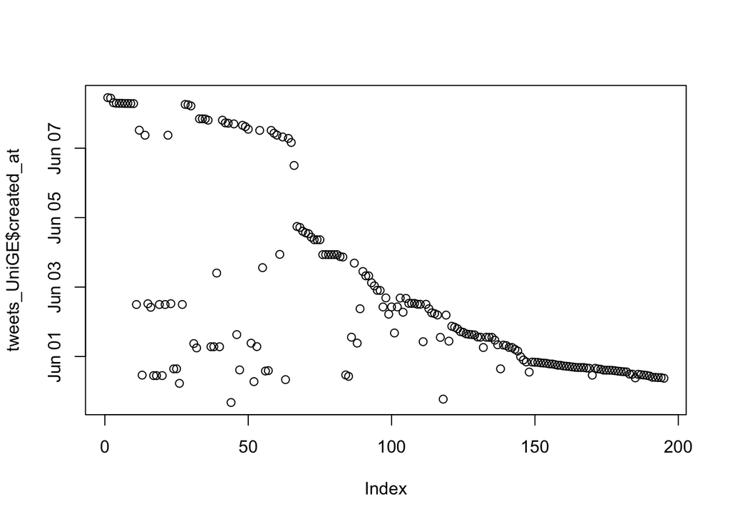

```r
plot(tweets_UniGE$created_at)
```

On peut faire mieux avec d’autres plackages, comme `ggplot2`

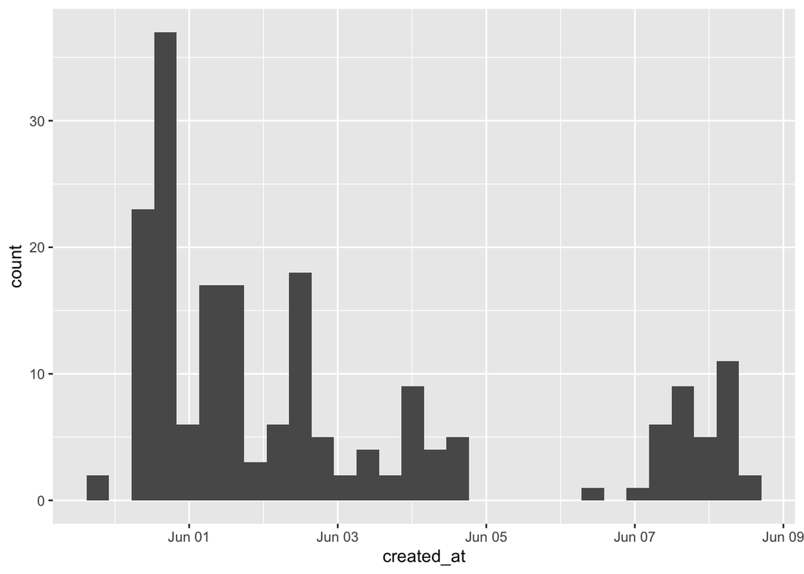

```r
#install.packages("ggplot2")
library(ggplot2)
nouv_graph<-ggplot(tweets_UniGE, aes(x = created_at)) + geom_histogram()
nouv_graph
```

Les dates sont des choses très standardisées: “YYYY-MM-DD Hh:Mm:Ss”

```r
head(tweets_UniGE$created_at)
```

```
## [1] "2022-06-08 10:57:56 UTC" "2022-06-08 10:37:13 UTC"
## [3] "2022-06-08 07:27:33 UTC" "2022-06-08 07:04:02 UTC"
## [5] "2022-06-08 07:01:51 UTC" "2022-06-08 07:01:32 UTC"
```

Il est donc facile de les manipuler, et il existe des fonctions déjà existantes que l’on peut réutiliser. Utilisées comme argument, elles permettent d’améliorer le rendu.

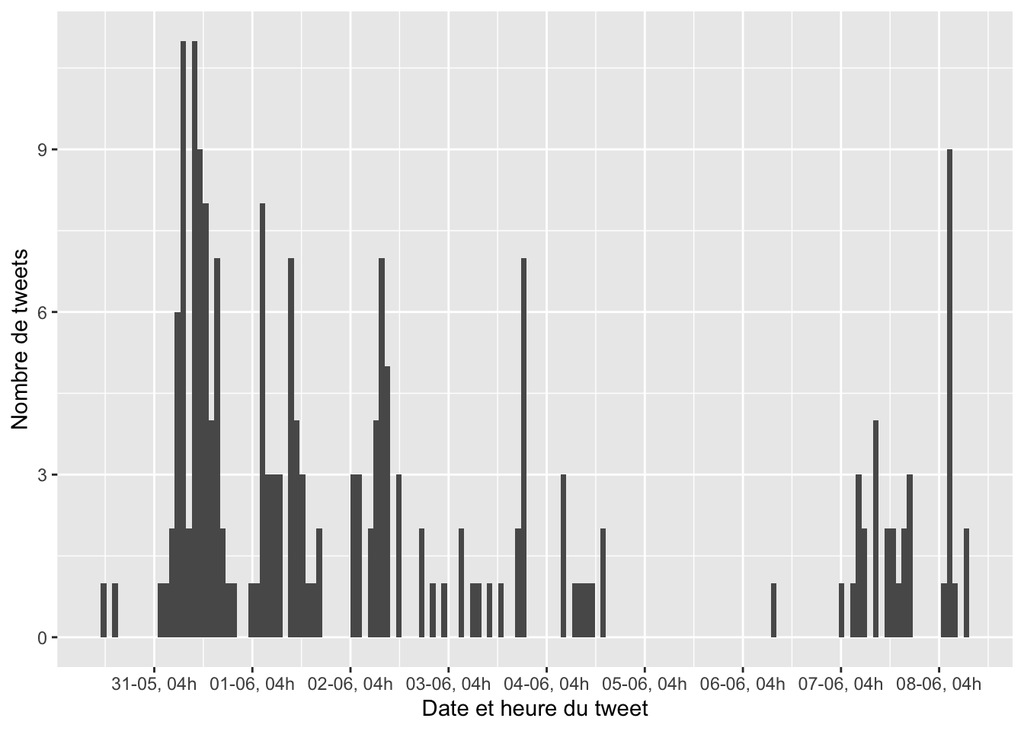

```r
#binwidth permet de paramétrer la largeur des barres
meilleur_graph<-ggplot(tweets_UniGE, aes(x = created_at)) + geom_histogram(binwidth = 5000) +
  # nous utilisons la fonction `scale_x_datetime` pour manipuler les données horaires
                scale_x_datetime(date_breaks = "24 hours",
                                 date_minor_breaks = "12 hours",
                                 date_labels = "%d-%m, %Hh",
                                 name = "Date et heure du tweet") +
                scale_y_continuous(name = "Nombre de tweets")
meilleur_graph
```

### Remerciements

Ce script s’inspire d’un cours de Y. Rochat (UniL)